# Taller III. Gestión Presupuestaria

Sebastian Freille

Universidad Nacional de Córdoba

# **Políticas Públicas y Presupuesto. Tipologías de presupuestos**

## Presupuesto por programas

- El **presupuesto por programas** busca eficacia de largo plazo mediante análisis y evaluación continua de programas públicos
- No es tan relevante en qué o cómo se gasta sino **la eficacia relativa de los programas alternativos** de gasto para alcanzar un objetivo
- Uno de los aspectos claves es identificar necesidades y objetivos y expresarlos en **indicadores cualitativos y cuantitativos**

## Presupuesto por programas (cont.)

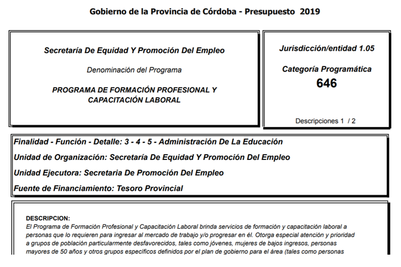

Presupuesto por programas

## Presupuesto por programas (cont.)

- La provincia de Córdoba viene hace varios años implementado un presupuesto por programas. En él se describen las necesidades, objetivos e indicadores
- Puede consultarse en el siguiente link (para el año 2024):
  - [Descripciones-de-Programas.pdf](https://drive.google.com/file/d/1DaRSAM4Ks6B4w6DHYywHwEP53Ggc1HJo/view?usp=drive_link)
- Más de **300 programas presupuestados** con sus respectivas descripciones y que atienden a diferentes áreas y necesidades

## Presupuesto por resultados

- **Conjunto de principios, procesos y herramientas aplicables a la gestión presupuestal**
- **Objetivo:**
  - Conectar la decisión de financiación y de acción (política) pública con cambios concretos sobre el ciudadano y su entorno en variables relevantes al desarrollo
- **Características:**
  - Basado en lógicas de causalidad y evidencia científica para las decisiones de política pública

## Presupuesto por resultados (cont.)

- Relaciones de causalidad entre **condiciones de interés (CI)**, factores e intervenciones
- Note que esto involucra un enfoque totalmente radical que contrasta con el ordenamiento de las cuentas públicas en clasificaciones presupuestarias tradicionales

## Presupuesto por resultados (cont.)

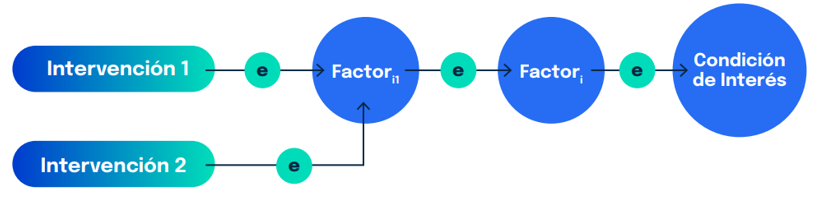

Diagrama básico

## Presupuesto por resultados (cont.)

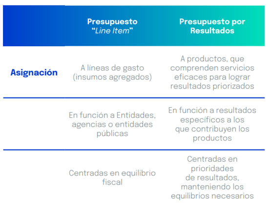

Asignación

## Presupuesto por resultados (cont.)

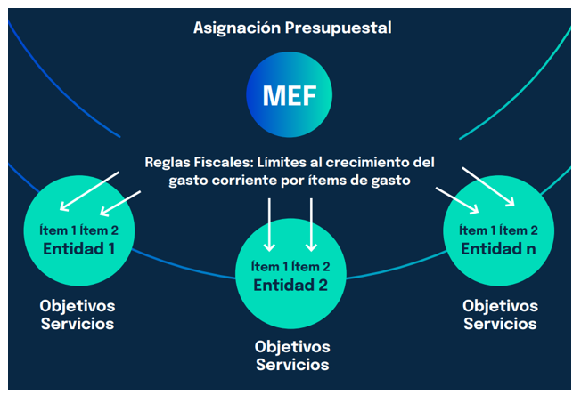

## Presupuesto por resultados (cont.)

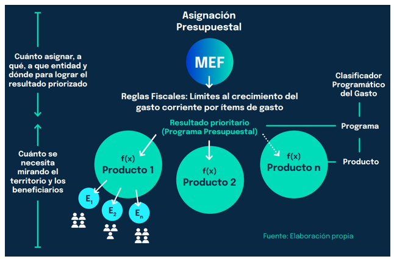

Objetivos, productos y beneficiarios (cont.)

# **El Programa Primer Paso (PPP)**

## El programa

- **Creado en 1999 por el gobierno provincial**
  - Es el programa de empleo focalizado más importante de la provincia de Córdoba
- **Objetivo:**
  - Promover y facilitar la transición hacia empleo formal de jóvenes de ambos sexos comprendidos entre 16 y 25 años en condición de desocupados y sin formación y/o experiencia laboral
- **Duración:**
  - 12 meses

## El programa PPP: diseño

| Cohorte | Tipo | Nro | Modalidad | Monto beca | Edades | Vigencia | Cupo | Cupo mínimo | Duración | Hs (dia/sem) |
| --- | --- | --- | --- | --- | --- | --- | --- | --- | --- | --- |
| 1999 | Decreto | 1759 | PPP | 140 | 16 a 25 | 01/09/99 al 31/08/00 | 10000 | 500 a departamentos de menor ingreso y 200 a discapacitados | 12 meses | 4/20 |
| 2012 | Decreto | 190 | PPP | 1000 | 16 a 25 | 01/06/12 al 31/05/13 | 10000 | 500 a departamentos de menor ingreso y 500 a discapacitados | 12 meses | 4/20 |
|  | Resolución | 167 |  |  |  |  |  |  |  | 4/20 |
| 2013 | Resolución | 8 | PPP | 1500 | 16 a 25 | 01/06/13 al 31/05/14 | 10000 | 500 a departamentos de menor ingreso y 500 a discapacitados | 12 meses | 4/20 |
|  | Resolución | 35 |  |  |  | 01/01/14 a 31/12/14 | 5000 (ampl) | 250 a departamentos de menor ingreso y 250 a discapacitados |  | 4/20 |

## El programa PPP: diseño (cont.)

| Cohorte | Tipo | Nro | Modalidad | Monto beca | Edades | Vigencia | Cupo | Cupo mínimo | Duración | Hs (dia/sem) |
| --- | --- | --- | --- | --- | --- | --- | --- | --- | --- | --- |
| 2014 | Ley | 10236 | PPP | 1500 | 16 a 25 | 01/07/14 a 30/06/14 | no menor a 15000 | 500 a departamentos de menor ingreso y 500 a discapacitados | 12 meses | 4/20 |
| 2015 | Ley | 10236 | PPP | 2500 | 16 a 25 | 01/07/15 al 30/06/16 | 15000 | 500 a departamentos de menor ingreso y 500 a discapacitados | 12 meses | 4/20 |
| 2016 | Resolución | 235 | Todos |  |  | 01/10/16 al 30/09/17 |  | No explicita | 12 meses | 4/20 |
|  | Decreto | 840 | PPP | 3000 | 16 a 24 | 01/09/16 al 31/08/17 | 8000 |  |  | 4/20 |
|  |  |  | PPPA | 3500 | 16 a 24 | 01/10/16 al 30/09/17 | 12000 |  |  | 4/20 |
|  | Resolución | 307 | PPP | 3500 | 16 a 24 | 01/10/16 al 30/09/17 | 2000 (ampl) | No explicita | 12 meses | 4/20 |

## El programa PPP: diseño (cont.)

| Cohorte | Tipo | Nro | Modalidad | Monto beca | Edades | Vigencia | Cupo | Cupo mínimo | Duración | Hs (dia/sem) |
| --- | --- | --- | --- | --- | --- | --- | --- | --- | --- | --- |
| 2016 (cont.) | Resolución | 691 | PPP | 3000 | 16 a 24 | 01/10/16 al 30/09/17 | 7500 | No explicita | 12 meses | 4/20 |
|  |  |  | PPPA | 3500 | 16 a 24 | 01/10/16 al 30/09/17 | 7000 |  |  | 4/20 |
| 2017 | Decreto | 1296 | Todos |  |  | 01/11/17 al 31/10/18 | 15000 | No explicita | 12 meses | 4/20 |
|  |  |  | PPP | 3500 | 16 a 24 | 01/11/17 al 31/10/18 |  |  |  | 4/20 |
|  |  |  | PPPA | 4000 | 16 a 24 | 01/11/17 al 31/10/18 |  |  |  | 4/20 |
|  | Resolución | 1132 | Todos |  |  |  | 15000 | No explicita | 12 meses | 4/20 |
|  |  |  | PPP | 3500 | 16 a 24 | 01/11/17 al 31/10/18 | 5000 |  |  | 4/20 |
|  |  |  | PPPA | 4000 | 16 a 24 | 01/11/17 al 31/10/18 | 8500 |  |  | 4/20 |

## El programa PPP: diseño (cont.)

- **Características adicionales del diseño:**
  - **Prohibición Organización Pública:** Varía según cohorte (No en 1999, Sí desde 2012, No en 2017)
  - **Prohibición Otro Subsidio:** Sí en la mayoría de las cohortes
  - **Elección:** Sistema de sorteo implementado desde 2012
  - **Exclusión Beneficiarios Previos:** Sí desde 2012

## El programa PPP: implementación y evaluación

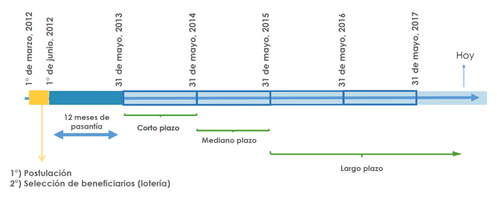

Diagrama de implementación

## El programa PPP: tratamiento y control

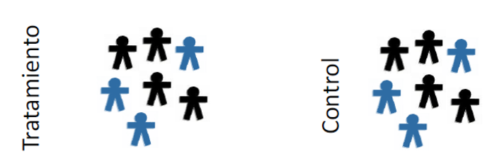

Grupos de tratamiento y control

## El programa PPP: tratamiento y control (cont.)

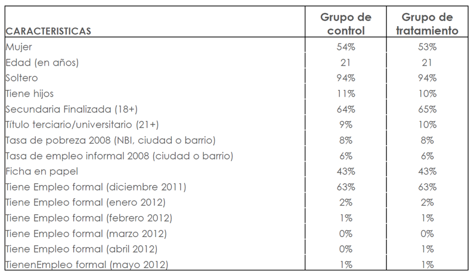

Características de los grupos

## El programa PPP: asignación geográfica

[figure not shown]

Distribución geográfica

## El programa PPP: resultados

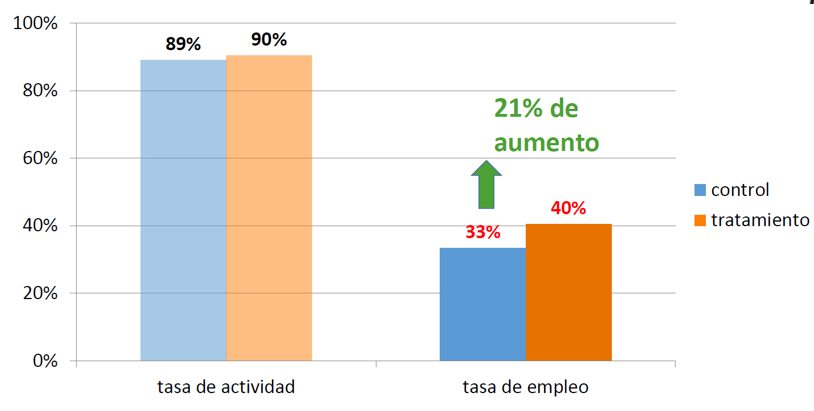

Resultados

## El programa PPP: resultados (cont.)

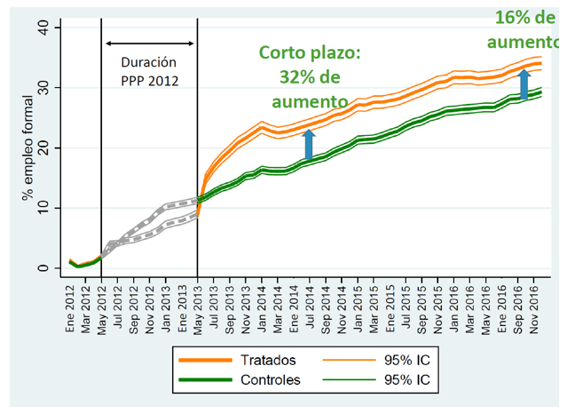

Resultados (cont.)